# Spectral parameterization for studying neurodevelopment: How and why

Illustrative example using the spectral parameterization (specparam) algorithm

Brendan Ostlund, Thomas Donoghue, Berenice Anaya, Kelley E. Gunther, Sarah L. Karalunas, Bradley Voytek, & Koraly E. Pérez-Edgar

This R Markdown file corresponds to data analysis for a **Developmental Cognitive Neuroscience** manuscript submitted as part of a special issue on EEG methods in developmental science in May, 2021. Participating families were a part of a study conducted by the [Cognition, Affect, and Temperament (CAT) lab, under the supervision of Koraly Pérez-Edgar](http://www.catlabpsu.com/) at Pennsylvania State University. The spectral parameterization ([specparam](https://fooof-tools.github.io/fooof/index.html)) algorithm was created by [Thomas Donoghue, Bradley Voytek, and colleagues from the Voytek lab](https://voyteklab.com/) at UC San Diego. Example data is available at the [Open Science Framework](https://osf.io/efj6c/) and GitHub pages for this project.

Analyses for the illustrative example are based on the eyes-closed condition of a resting baseline task (*n* = 60). Please see the corresponding manuscript for more details. A few code chunks described the “R_groupPSD.Rmd” tutorial have been merged in the script below to reduce length.

**Note:** Demographic information was reported in the manuscript but are not examined here in order to protect confidentiality of our participants.

## **1.** Prepare data

### Load data

```r
setwd("~/Desktop/specparam")

data <- read.csv("ecl.csv", header= TRUE)
PSDs <- read.csv("eclPSDs.csv", header= TRUE)
freq <- read.csv("freqs.csv", header= TRUE)
```

### Load R libraries

```r
library(tidyverse)   # Access a collection of packages for data management (e.g., dplyr, ggplot2, readr)
library(reticulate)  # Interface Python and R Studio
library(magick)      # Load and adjust .PNG files
library(gridExtra)   # Arrange multiple plots

library(psych)       # Toolbox for data analysis
library(sjstats)     # Toolbox for data analysis
library(ggpubr)      # Additional tools for data visualization
```

### Load python libraries

```python
import pandas as pd
import numpy as np
import sys
import os
import matplotlib
import tqdm
import pytest

from fooof import FOOOFGroup
from fooof.bands import Bands
from fooof.analysis import get_band_peak_fg
from fooof.plts.periodic import plot_peak_fits, plot_peak_params
from fooof.plts.aperiodic import plot_aperiodic_params, plot_aperiodic_fits
```

### Miscellaneous functions

The *extract_legend* function was created by [Joachim Schork](https://statisticsglobe.com/add-common-legend-to-combined-ggplot2-plots-in-r/). The *spread_n* function was pulled from this [post](https://community.rstudio.com/t/spread-with-multiple-value-columns/5378) from the RStudio Community website.

```r
extract_legend <-
  function(my_ggp) {
    step1 <- ggplot_gtable(ggplot_build(my_ggp))
    step2 <- which(sapply(step1$grobs, function(x) x$name)== "guide-box")
    step3 <- step1$grobs[[step2]]
    return(step3)
    }

spread_n <-
  function(df, key, value) {
    keyq <- rlang::enquo(key)
    valueq <- rlang::enquo(value)
    s <- rlang::quos(!!valueq)
    df %>% gather(variable, value, !!!s) %>%
    unite(temp, !!keyq, variable) %>%
    spread(temp, value)
    }
```

## **2.** Compare fitted group power spectra

### Load group PSDs

```python
freqs= np.ravel(pd.read_csv("freqs.csv"))
spectra= np.array(pd.read_csv("eclPSDs.csv"))

print(freqs.shape)
```

```
## (50,)
```

```python
print(spectra.shape)
```

```
## (60, 50)
```

### Fit group PSDs

```python
fg= FOOOFGroup(peak_width_limits= [1, 8], max_n_peaks= 8, min_peak_height= 0.05, verbose= 'FALSE')
fg.fit(freqs, spectra, [1, 50])
```

```
## Running FOOOFGroup across 60 power spectra.
##
## FOOOF WARNING: Lower-bound peak width limit is < or ~= the frequency resolution: 1.00 <= 1.00
##  Lower bounds below frequency-resolution have no effect (effective lower bound is the frequency resolution).
##  Too low a limit may lead to overfitting noise as small bandwidth peaks.
##  We recommend a lower bound of approximately 2x the frequency resolution.
```

```python
fg.print_results()
```

```
## ==================================================================================================
##
##                                        FOOOF - GROUP RESULTS
##
##                              Number of power spectra in the Group: 60
##
##                         The model was run on the frequency range 1 - 50 Hz
##                                  Frequency Resolution is 1.00 Hz
##
##                               Power spectra were fit without a knee.
##
##                                       Aperiodic Fit Values:
##                         Exponents - Min:  1.201, Max:  1.949, Mean: 1.572
##
##                          In total 164 peaks were extracted from the group
##
##                                      Goodness of fit metrics:
##                             R2s -  Min:  0.976, Max:  0.999, Mean: 0.994
##                          Errors -  Min:  0.019, Max:  0.083, Mean: 0.041
##
## ==================================================================================================
##
```

```python
fg.save_report('ECL_example')
fg.plot(save_fig= True, file_name= "ECL_example")
fg_aps= fg.get_params('aperiodic_params')
fg_r2s= fg.get_params('r_squared')
fg_errors= fg.get_params('error')

bands= Bands({'delta':[1, 4], 'theta':[4, 8], 'alpha':[8, 13], 'beta':[13, 30], 'gamma':[30, 50]})
deltas= get_band_peak_fg(fg, bands.delta)
thetas= get_band_peak_fg(fg, bands.theta)
alphas= get_band_peak_fg(fg, bands.alpha)
betas=  get_band_peak_fg(fg, bands.beta)
gammas= get_band_peak_fg(fg, bands.gamma)
```

### Save to R data frame

```r
aps <- as.data.frame(py$fg_aps) %>% rename(offset= 1, exponent= 2)
r2s <- as.data.frame(py$fg_r2s) %>% rename(r2s= 1)
err <- as.data.frame(py$fg_errors) %>% rename(error= 1)

deltas <- as.data.frame(py$deltas) %>%
           rename(CF_delta= 1, PW_delta= 2, BW_delta= 3) %>%
           mutate_at(vars(1:3), ~ifelse(.== "NaN", NA, .))
thetas <- as.data.frame(py$thetas) %>%
           rename(CF_theta= 1, PW_theta= 2, BW_theta= 3) %>%
           mutate_at(vars(1:3), ~ifelse(.== "NaN", NA, .))
alphas <- as.data.frame(py$alphas) %>%
           rename(CF_alpha= 1, PW_alpha= 2, BW_alpha= 3) %>%
           mutate_at(vars(1:3), ~ifelse(.== "NaN", NA, .))
betas  <- as.data.frame(py$betas) %>%
           rename(CF_beta= 1, PW_beta= 2, BW_beta= 3) %>%
           mutate_at(vars(1:3), ~ifelse(.== "NaN", NA, .))
gammas <- as.data.frame(py$gammas) %>%
           rename(CF_gamma= 1, PW_gamma= 2, BW_gamma= 3) %>%
           mutate_at(vars(1:3), ~ifelse(.== "NaN", NA, .))

dat_param <- data %>%
              select(ID:GRP) %>%
              cbind(., aps, r2s, err, deltas, thetas, alphas, betas, gammas) %>%
              mutate(GRP= recode(GRP, BLN= "BI", NT= "BN"))
write.csv(dat_param, "ECL_example.csv", row.names= FALSE)
```

### Descriptive information

```r
dat_param %>% describe(skew= FALSE)
```

```
##          vars  n   mean    sd    min    max range   se
## ID          1 60 130.50 17.46 101.00 160.00 59.00 2.25
## GRP*        2 60   1.50  0.50   1.00   2.00  1.00 0.07
## offset      3 60   1.42  0.18   1.06   1.83  0.77 0.02
## exponent    4 60   1.57  0.16   1.20   1.95  0.75 0.02
## r2s         5 60   0.99  0.00   0.98   1.00  0.02 0.00
## error       6 60   0.04  0.01   0.02   0.08  0.06 0.00
## CF_delta    7  0    NaN    NA    Inf   -Inf  -Inf   NA
## PW_delta    8  0    NaN    NA    Inf   -Inf  -Inf   NA
## BW_delta    9  0    NaN    NA    Inf   -Inf  -Inf   NA
## CF_theta   10 13   5.97  1.18   4.20   7.91  3.71 0.33
## PW_theta   11 13   0.41  0.22   0.13   0.92  0.79 0.06
## BW_theta   12 13   1.81  0.52   1.00   2.83  1.83 0.14
## CF_alpha   13 58   9.66  0.64   8.56  11.72  3.17 0.08
## PW_alpha   14 58   1.00  0.27   0.30   1.56  1.26 0.04
## BW_alpha   15 58   2.97  0.99   1.00   6.27  5.27 0.13
## CF_beta    16 48  17.71  2.35  13.35  21.35  8.00 0.34
## PW_beta    17 48   0.33  0.15   0.14   0.90  0.76 0.02
## BW_beta    18 48   5.16  2.03   2.21   8.00  5.79 0.29
## CF_gamma   19 18  37.31  7.23  30.57  49.41 18.85 1.70
## PW_gamma   20 18   0.24  0.12   0.09   0.52  0.43 0.03
## BW_gamma   21 18   3.33  2.40   1.00   8.00  7.00 0.57
```

```r
dat_param %>% filter(GRP== "BI") %>% describe(skew= FALSE)
```

```
##          vars  n   mean    sd    min    max range   se
## ID          1 30 128.40 19.68 101.00 160.00 59.00 3.59
## GRP*        2 30   1.00  0.00   1.00   1.00  0.00 0.00
## offset      3 30   1.43  0.18   1.07   1.83  0.77 0.03
## exponent    4 30   1.58  0.18   1.22   1.95  0.73 0.03
## r2s         5 30   0.99  0.01   0.98   1.00  0.02 0.00
## error       6 30   0.04  0.02   0.02   0.08  0.06 0.00
## CF_delta    7  0    NaN    NA    Inf   -Inf  -Inf   NA
## PW_delta    8  0    NaN    NA    Inf   -Inf  -Inf   NA
## BW_delta    9  0    NaN    NA    Inf   -Inf  -Inf   NA
## CF_theta   10  4   6.08  1.35   4.65   7.91  3.26 0.68
## PW_theta   11  4   0.42  0.28   0.13   0.79  0.66 0.14
## BW_theta   12  4   2.07  0.53   1.62   2.83  1.21 0.26
## CF_alpha   13 28   9.90  0.69   8.62  11.72  3.10 0.13
## PW_alpha   14 28   1.08  0.25   0.30   1.56  1.26 0.05
## BW_alpha   15 28   2.96  1.19   1.00   6.27  5.27 0.23
## CF_beta    16 25  18.33  2.30  13.39  21.35  7.96 0.46
## PW_beta    17 25   0.35  0.17   0.15   0.90  0.75 0.03
## BW_beta    18 25   5.46  1.95   2.21   8.00  5.79 0.39
## CF_gamma   19  9  36.45  6.70  30.61  49.41 18.81 2.23
## PW_gamma   20  9   0.24  0.09   0.10   0.41  0.30 0.03
## BW_gamma   21  9   2.74  2.06   1.00   8.00  7.00 0.69
```

```r
dat_param %>% filter(GRP== "BN") %>% describe(skew= FALSE)
```

```
##          vars  n   mean    sd    min    max range   se
## ID          1 30 132.60 14.96 106.00 159.00 53.00 2.73
## GRP*        2 30   1.00  0.00   1.00   1.00  0.00 0.00
## offset      3 30   1.40  0.17   1.06   1.71  0.65 0.03
## exponent    4 30   1.56  0.13   1.20   1.75  0.55 0.02
## r2s         5 30   0.99  0.00   0.98   1.00  0.02 0.00
## error       6 30   0.04  0.01   0.02   0.07  0.05 0.00
## CF_delta    7  0    NaN    NA    Inf   -Inf  -Inf   NA
## PW_delta    8  0    NaN    NA    Inf   -Inf  -Inf   NA
## BW_delta    9  0    NaN    NA    Inf   -Inf  -Inf   NA
## CF_theta   10  9   5.92  1.18   4.20   7.38  3.18 0.39
## PW_theta   11  9   0.40  0.22   0.19   0.92  0.72 0.07
## BW_theta   12  9   1.70  0.50   1.00   2.57  1.57 0.17
## CF_alpha   13 30   9.45  0.50   8.56  10.54  1.98 0.09
## PW_alpha   14 30   0.92  0.27   0.38   1.41  1.03 0.05
## BW_alpha   15 30   2.97  0.78   1.78   5.18  3.39 0.14
## CF_beta    16 23  17.04  2.25  13.35  19.93  6.58 0.47
## PW_beta    17 23   0.31  0.11   0.14   0.59  0.45 0.02
## BW_beta    18 23   4.83  2.11   2.33   8.00  5.67 0.44
## CF_gamma   19  9  38.17  8.03  30.57  47.94 17.38 2.68
## PW_gamma   20  9   0.24  0.14   0.09   0.52  0.43 0.05
## BW_gamma   21  9   3.92  2.69   1.43   8.00  6.57 0.90
```

### Print group fit results

```
## # A tibble: 1 x 7
##   format width height colorspace matte filesize density
##   <chr>  <int>  <int> <chr>      <lgl>    <int> <chr>
## 1 PNG     1200   1000 sRGB       TRUE     81864 39x39
```

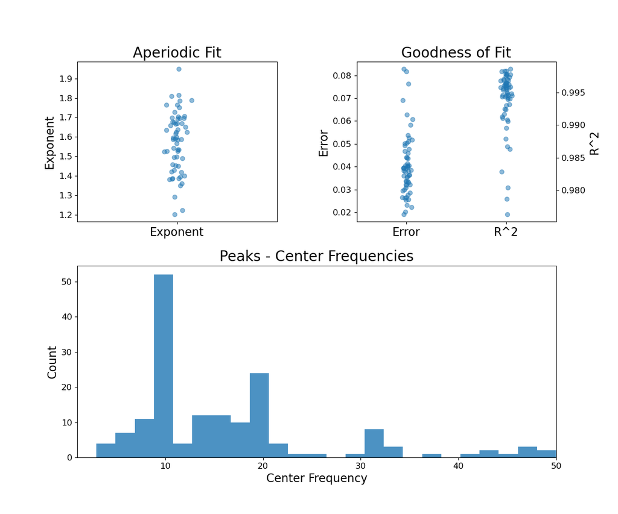

```r
print(image_read("~/Desktop/specparam/ECL_example.png"))
```

### Plot periodic and aperiodic parameters

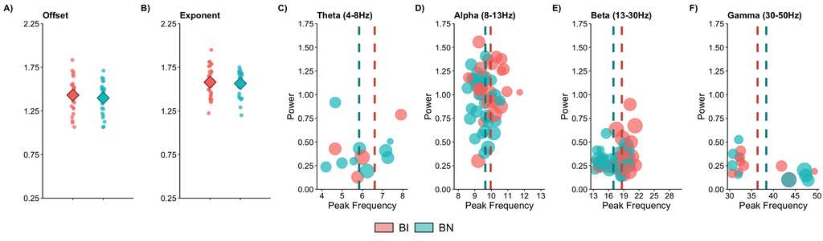

```r
fig5a <- ggplot(dat_param, aes(x= GRP, y= offset, fill= GRP)) +
          geom_jitter(alpha= 0.7, width= 0.05, size= 2, aes(color= GRP)) +
          theme_classic() +
          labs(tag= "A)", title= "Offset") +
          stat_summary(fun.y=mean, shape= 23, size= 1.5, color= c("coral4","cyan4")) +
          scale_x_discrete(name= "", expand= c(1, 0), labels= NULL) +
          scale_y_continuous(name= "", limits= c(0.25,2.25), breaks= seq(0.25,2.25,0.5), expand= c(0, 0)) +
          theme(axis.text= element_text(size= 12, color= "black"), axis.title= element_text(size= 14),
               plot.tag= element_text(face= "bold"), plot.title= element_text(face= "bold")) +
          theme(legend.position= "none")

fig5b <- ggplot(dat_param, aes(x= GRP, y= exponent, fill= GRP)) +
          geom_jitter(alpha= 0.7, width= 0.05, size= 2, aes(color= GRP)) +
          theme_classic() +
          labs(tag= "B)", title= "Exponent") +
          stat_summary(fun.y=mean, shape= 23, size= 1.5, color= c("coral4","cyan4")) +
          scale_x_discrete(name= "", expand= c(1, 0), labels= NULL) +
          scale_y_continuous(name= "", limits= c(0.25,2.25), breaks= seq(0.25,2.25,0.5), expand= c(0, 0)) +
          theme(axis.text= element_text(size= 12, color= "black"), axis.title= element_text(size= 14),
               plot.tag= element_text(face= "bold"), plot.title= element_text(face= "bold")) +
          theme(legend.position= "none")

fig5c <- ggplot(dat_param, aes(x= CF_theta, y= PW_theta, size= BW_theta, fill= BW_theta, color= GRP)) +
          geom_point(alpha= 0.7) +
          theme_classic() +
          labs(tag= "C)", title= "Theta (4-8Hz)") +
          scale_x_continuous(name= "Peak Frequency",
                             limits= c(3.75,8.25), breaks= seq(4,8, by= 1), expand= c(0,0)) +
          scale_y_continuous(name= "Power", limits= c(0,1.75), breaks= seq(-0,1.75, by= 0.25), expand= c(0,0)) +
          theme(axis.text= element_text(size= 12, color= "black"), axis.title= element_text(size= 14),
                plot.tag= element_text(face= "bold"), plot.title= element_text(face= "bold")) +
          scale_size(range = c(4, 10)) +
          geom_vline(xintercept= 6.61, linetype= "dashed", color= "coral3", size= 1.50) +
          geom_vline(xintercept= 5.84, linetype= "dashed", color= "darkcyan", size= 1.50) +
          theme(legend.position= "none")

fig5d <- ggplot(dat_param, aes(x= CF_alpha, y= PW_alpha, size= BW_alpha, fill= BW_alpha, color= GRP)) +
          geom_point(alpha= 0.7) +
          theme_classic() +
          labs(tag= "D)",  title= "Alpha (8-13Hz)") +
          scale_x_continuous(name= "Peak Frequency",
                             limits= c(7.75,13.25), breaks= seq(8,13, by= 1), expand= c(0,0)) +
          scale_y_continuous(name= "Power", limits= c(0,1.75), breaks= seq(-0,1.75, by= 0.25), expand= c(0,0)) +
          theme(axis.text= element_text(size= 12, color= "black"), axis.title= element_text(size= 14),
                plot.tag= element_text(face= "bold"), plot.title= element_text(face= "bold")) +
          scale_size(range = c(4, 10)) +
          geom_vline(xintercept= 9.96, linetype= "dashed", color= "coral3", size= 1.50) +
          geom_vline(xintercept= 9.64, linetype= "dashed", color= "darkcyan", size= 1.50) +
          theme(legend.position= "none")

fig5e <- ggplot(dat_param, aes(x= CF_beta, y= PW_beta, size= BW_beta, fill= BW_beta, color= GRP)) +
          geom_point(alpha= 0.7) +
          theme_classic() +
          labs(tag= "E)", title= "Beta (13-30Hz)") +
          scale_x_continuous(name= "Peak Frequency",
                             limits= c(12.50,30.50), breaks= seq(13,30, by= 3), expand= c(0,0)) +
          scale_y_continuous(name= "Power", limits= c(0,1.75), breaks= seq(-0,1.75, by= 0.25), expand= c(0,0)) +
          theme(axis.text= element_text(size= 12, color= "black"), axis.title= element_text(size= 14),
                plot.tag= element_text(face= "bold"), plot.title= element_text(face= "bold")) +
          scale_size(range = c(4, 10)) +
          geom_vline(xintercept= 18.62, linetype= "dashed", color= "coral3", size= 1.50) +
          geom_vline(xintercept= 16.96, linetype= "dashed", color= "darkcyan", size= 1.50) +
          theme(legend.position= "none")

fig5f <- ggplot(dat_param, aes(x= CF_gamma, y= PW_gamma, size= BW_gamma, fill= BW_gamma, color= GRP)) +
          geom_point(alpha= 0.7) +
          theme_classic() +
          labs(tag= "F)", title= "Gamma (30-50Hz)") +
          scale_x_continuous(name= "Peak Frequency",
                             limits= c(29.50,50.50), breaks= seq(30,50, by= 5), expand= c(0,0)) +
          scale_y_continuous(name= "Power", limits= c(0,1.75), breaks= seq(-0,1.75, by= 0.25), expand= c(0,0)) +
          theme(axis.text= element_text(size= 12, color= "black"), axis.title= element_text(size= 14),
                plot.tag= element_text(face= "bold"), plot.title= element_text(face= "bold")) +
          scale_size(range = c(4, 10)) +
          geom_vline(xintercept= 36.39, linetype= "dashed", color= "coral3", size= 1.50) +
          geom_vline(xintercept= 38.37, linetype= "dashed", color= "darkcyan", size= 1.50) +
          theme(legend.position= "none")

legend <- ggplot(dat_param, aes(x= CF_gamma, fill= GRP)) +
           geom_density(alpha= 0.5) +
           scale_fill_discrete(name= "", labels= c("BI", "BN")) +
           theme(legend.position= "bottom") +
           theme(legend.title= element_text(size= 16, face= "bold"), legend.text= element_text(size = 16),
                 legend.key.height= unit(0.50, 'cm'), legend.key.width= unit(1, 'cm'))

shared_legend <- extract_legend(legend)
grid.arrange(arrangeGrob(fig5a, fig5b, fig5c, fig5d, fig5e, fig5f, nrow= 1), shared_legend, heights= c(8, 1))
```

### Group comparisons of periodic and aperiodic activity

```r
t.test(offset~ GRP, data= dat_param, var.equal= TRUE)
```

```
##
##  Two Sample t-test
##
## data:  offset by GRP
## t = 0.73451, df = 58, p-value = 0.4656
## alternative hypothesis: true difference in means is not equal to 0
## 95 percent confidence interval:
##  -0.05749833  0.12415369
## sample estimates:
## mean in group BI mean in group BN
##         1.432025         1.398697
```

```r
t.test(exponent~ GRP, data= dat_param, var.equal= TRUE)
```

```
##
##  Two Sample t-test
##
## data:  exponent by GRP
## t = 0.3918, df = 58, p-value = 0.6966
## alternative hypothesis: true difference in means is not equal to 0
## 95 percent confidence interval:
##  -0.06522777  0.09697639
## sample estimates:
## mean in group BI mean in group BN
##         1.579881         1.564007
```

```r
t.test(CF_alpha~ GRP, data= dat_param, var.equal= TRUE)
```

```
##
##  Two Sample t-test
##
## data:  CF_alpha by GRP
## t = 2.8675, df = 56, p-value = 0.005821
## alternative hypothesis: true difference in means is not equal to 0
## 95 percent confidence interval:
##  0.1359556 0.7662099
## sample estimates:
## mean in group BI mean in group BN
##         9.896650         9.445567
```

```r
t.test(PW_alpha~ GRP, data= dat_param, var.equal= TRUE)
```

```
##
##  Two Sample t-test
##
## data:  PW_alpha by GRP
## t = 2.27, df = 56, p-value = 0.02708
## alternative hypothesis: true difference in means is not equal to 0
## 95 percent confidence interval:
##  0.01830191 0.29320943
## sample estimates:
## mean in group BI mean in group BN
##        1.0788221        0.9230665
```

```r
t.test(BW_alpha~ GRP, data= dat_param, var.equal= TRUE)
```

```
##
##  Two Sample t-test
##
## data:  BW_alpha by GRP
## t = -0.023372, df = 56, p-value = 0.9814
## alternative hypothesis: true difference in means is not equal to 0
## 95 percent confidence interval:
##  -0.5329432  0.5206508
## sample estimates:
## mean in group BI mean in group BN
##         2.962233         2.968379
```

```r
t.test(CF_beta~ GRP, data= dat_param, var.equal= TRUE)
```

```
##
##  Two Sample t-test
##
## data:  CF_beta by GRP
## t = 1.9734, df = 46, p-value = 0.05448
## alternative hypothesis: true difference in means is not equal to 0
## 95 percent confidence interval:
##  -0.02600978  2.62217395
## sample estimates:
## mean in group BI mean in group BN
##         18.33492         17.03684
```

```r
t.test(PW_beta~ GRP, data= dat_param, var.equal= TRUE)
```

```
##
##  Two Sample t-test
##
## data:  PW_beta by GRP
## t = 1.0457, df = 46, p-value = 0.3011
## alternative hypothesis: true difference in means is not equal to 0
## 95 percent confidence interval:
##  -0.04096786  0.12956058
## sample estimates:
## mean in group BI mean in group BN
##        0.3524823        0.3081860
```

```r
t.test(BW_beta~ GRP, data= dat_param, var.equal= TRUE)
```

```
##
##  Two Sample t-test
##
## data:  BW_beta by GRP
## t = 1.0823, df = 46, p-value = 0.2848
## alternative hypothesis: true difference in means is not equal to 0
## 95 percent confidence interval:
##  -0.5447864  1.8118582
## sample estimates:
## mean in group BI mean in group BN
##         5.461121         4.827585
```

## **3.** Compare frontal alpha asymmetry calculation methods

### Calculate frontal asymmetry using traditional analysis

```r
trad <- read.csv("asm.csv", header= TRUE) %>%
         select(-c(X01:X07,X14:X50)) %>%
         mutate(X08= log10(X08), X09= log10(X09), X10= log10(X10),
                X11= log10(X11), X12= log10(X12), X13= log10(X13)) %>%
         mutate(alpha= mean_n(.[c(4:9)], 1)) %>%
         select(ID,GRP,hem,alpha) %>%
         spread(hem,alpha) %>%
         mutate(ASM_trad= right - left)
```

### Calculate specparam frontal asymmetry

#### Load group PSDs

```python
freqs= np.ravel(pd.read_csv("freqs.csv"))
spectra= np.array(pd.read_csv("asmPSDs.csv"))
print(freqs.shape)
```

```
## (50,)
```

```python
print(spectra.shape)
```

```
## (120, 50)
```

### Fit group PSDs

```python
fg= FOOOFGroup(peak_width_limits= [1, 8], max_n_peaks= 8, min_peak_height= 0.05, verbose= 'FALSE')
fg.fit(freqs, spectra, [1, 50])
```

```
## Running FOOOFGroup across 120 power spectra.
##
## FOOOF WARNING: Lower-bound peak width limit is < or ~= the frequency resolution: 1.00 <= 1.00
##  Lower bounds below frequency-resolution have no effect (effective lower bound is the frequency resolution).
##  Too low a limit may lead to overfitting noise as small bandwidth peaks.
##  We recommend a lower bound of approximately 2x the frequency resolution.
```

```python
fg.print_results()
```

```
## ==================================================================================================
##
##                                        FOOOF - GROUP RESULTS
##
##                             Number of power spectra in the Group: 120
##
##                         The model was run on the frequency range 1 - 50 Hz
##                                  Frequency Resolution is 1.00 Hz
##
##                               Power spectra were fit without a knee.
##
##                                       Aperiodic Fit Values:
##                         Exponents - Min:  0.979, Max:  1.973, Mean: 1.652
##
##                          In total 417 peaks were extracted from the group
##
##                                      Goodness of fit metrics:
##                             R2s -  Min:  0.914, Max:  0.998, Mean: 0.991
##                          Errors -  Min:  0.022, Max:  0.099, Mean: 0.048
##
## ==================================================================================================
##
```

```python
fg.save_report('ASM_example')
fg.plot(save_fig= True, file_name= "ASM_example")
band = Bands({'alpha' : [8, 13]})
alphas= get_band_peak_fg(fg, band.alpha)
fg_aps= fg.get_params('aperiodic_params')
```

#### Save to R dataframe

```r
alphas <- as.data.frame(py$alphas) %>%
            rename(CF_alpha= 1, PW_alpha= 2, BW_alpha= 3) %>%
            mutate_at(vars(1:3), ~ifelse(.== "NaN", NA, .))

aps <- as.data.frame(py$fg_aps) %>% rename(offset= 1, exponent= 2)

asm <- read.csv("asm.csv", header= TRUE) %>%
        select(ID:hem) %>%
        cbind(alphas, aps)

write.csv(asm, "ASM_example.csv", row.names= FALSE)

specparam <- asm %>%
              group_by(ID) %>%
              filter(!is.na(PW_alpha)) %>%
              summarise(missing_lat= all(PW_alpha== PW_alpha[1L])) %>%
              filter(missing_lat== FALSE) %>%
              left_join(., asm, by= "ID") %>%
              select(ID,GRP,hem,PW_alpha,exponent) %>%
              spread_n(hem,c(PW_alpha,exponent)) %>%
              mutate(ASM_param= right_PW_alpha - left_PW_alpha, exp_lateralized= right_exponent - left_exponent)

asm.wide <- left_join(trad, specparam, by= c("ID","GRP")) %>% mutate(GRP= recode(GRP, BLN= "BI", NT= "BN"))
```

### Compare measurement approaches

```r
asm.wide %>% filter(GRP== "BI") %>% select(ASM_trad,ASM_param) %>% describe(skew= FALSE)
```

```
##           vars  n  mean   sd   min  max range   se
## ASM_trad     1 30 -0.02 0.09 -0.22 0.14  0.36 0.02
## ASM_param    2 28  0.01 0.13 -0.24 0.40  0.64 0.02
```

```r
asm.wide %>% filter(GRP== "BN") %>% select(ASM_trad,ASM_param) %>% describe(skew= FALSE)
```

```
##           vars  n  mean   sd   min  max range   se
## ASM_trad     1 30 -0.03 0.10 -0.26 0.21  0.47 0.02
## ASM_param    2 29  0.01 0.13 -0.26 0.31  0.56 0.02
```

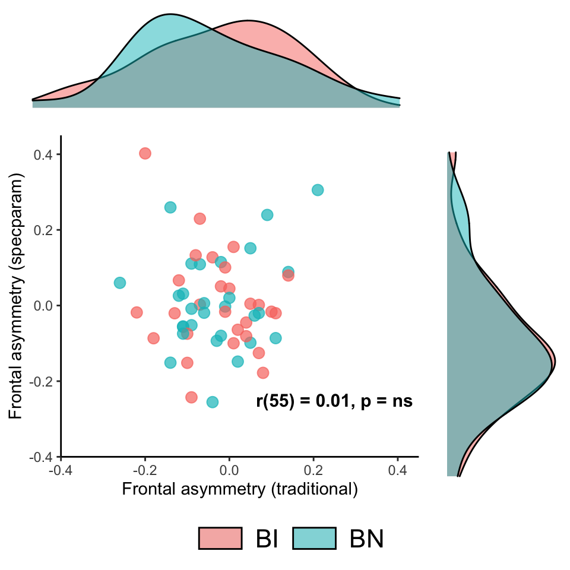

```r
fig5g <- ggscatter(asm.wide, x= "ASM_trad", y= "ASM_param", color= "GRP", size= 3, alpha= 0.7) +
          theme_classic() +
          scale_x_continuous(name= "Frontal asymmetry (traditional)",
                             limits= c(-.40,.45), breaks= seq(-.40,0.5,0.2), expand= c(0, 0)) +
          scale_y_continuous(name= "Frontal asymmetry (specparam)",
                             limits= c(-.40,.45), breaks= seq(-.40,0.5,0.2), expand= c(0, 0)) +
          annotate("text", x= 0.25, y= -0.25, label= "r(55) = 0.01, p = ns", fontface= "bold", size= 4) +
          theme(legend.position= "none")
xplot <- ggdensity(asm.wide, "ASM_trad", fill= "GRP") +
          clean_theme() +
          theme(legend.position= "none")
yplot <- ggdensity(asm.wide, "ASM_param", fill= "GRP") +
          clean_theme() +
          theme(legend.position= "none") +
          rotate()
layout1 <- rbind(c(2,2,2,NA), c(1,1,1,3), c(1,1,1,3), c(1,1,1,3))
grid.arrange(arrangeGrob(fig5g, xplot, yplot, layout_matrix= layout1), shared_legend, heights= c(8, 1))
```

```r
cor.test(asm.wide$ASM_trad, asm.wide$ASM_param, method= "pearson")
```

```
##
##  Pearson's product-moment correlation
##
## data:  asm.wide$ASM_trad and asm.wide$ASM_param
## t = 0.056156, df = 55, p-value = 0.9554
## alternative hypothesis: true correlation is not equal to 0
## 95 percent confidence interval:
##  -0.2534959  0.2676115
## sample estimates:
##         cor
## 0.007571884
```

```r
t.test(ASM_trad~ GRP, data= asm.wide, var.equal= TRUE)
```

```
##
##  Two Sample t-test
##
## data:  ASM_trad by GRP
## t = 0.42915, df = 58, p-value = 0.6694
## alternative hypothesis: true difference in means is not equal to 0
## 95 percent confidence interval:
##  -0.03908629  0.06041963
## sample estimates:
## mean in group BI mean in group BN
##      -0.02200000      -0.03266667
```

```r
t.test(ASM_param~ GRP, data= asm.wide, var.equal= TRUE)
```

```
##
##  Two Sample t-test
##
## data:  ASM_param by GRP
## t = -0.13383, df = 55, p-value = 0.894
## alternative hypothesis: true difference in means is not equal to 0
## 95 percent confidence interval:
##  -0.07289446  0.06376815
## sample estimates:
## mean in group BI mean in group BN
##      0.005631745      0.010194901
```

```r
asm.long <- asm.wide %>%
             group_by(ID) %>%
             select(ID,GRP,ASM_trad,ASM_param) %>%
             gather("ASM_trad", "ASM_param", key= Method, value= Score) %>%
             arrange(ID)

asm.long_trad <- asm.long %>% filter(Method== "ASM_trad")
wilcox.test(Score ~ GRP, data= asm.long_trad, exact= FALSE, conf.int= TRUE, conf.level= 0.95)
```

```
##
##  Wilcoxon rank sum test with continuity correction
##
## data:  Score by GRP
## W = 498.5, p-value = 0.4778
## alternative hypothesis: true location shift is not equal to 0
## 95 percent confidence interval:
##  -0.03998983  0.07006837
## sample estimates:
## difference in location
##             0.01994243
```

```r
asm.long_spec <- asm.long %>% filter(Method== "ASM_param")
wilcox.test(Score ~ GRP, data= asm.long_spec, exact= FALSE, conf.int= TRUE, conf.level= 0.95)
```

```
##
##  Wilcoxon rank sum test with continuity correction
##
## data:  Score by GRP
## W = 395, p-value = 0.8669
## alternative hypothesis: true location shift is not equal to 0
## 95 percent confidence interval:
##  -0.06915164  0.05912389
## sample estimates:
## difference in location
##           -0.003659858
```

### Examine exponent lateralization

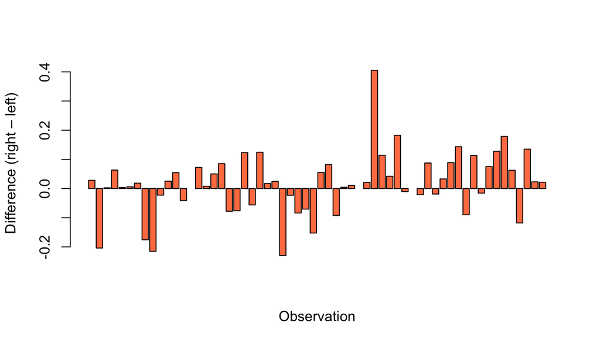

```r
diff <- asm.wide$right_exponent - asm.wide$left_exponent
barplot(diff, col= "coral", xlab= "Observation", ylab= "Difference (right – left)")
```

```r
cor.test(asm.wide$right_exponent, asm.wide$left_exponent, method= "pearson")
```

```
##
##  Pearson's product-moment correlation
##
## data:  asm.wide$right_exponent and asm.wide$left_exponent
## t = 11.181, df = 55, p-value = 8.792e-16
## alternative hypothesis: true correlation is not equal to 0
## 95 percent confidence interval:
##  0.7316688 0.8987625
## sample estimates:
##       cor
## 0.8333575
```

```r
asm.wide %>% filter(GRP== "BI") %>% select(exp_lateralized) %>% describe(skew= FALSE)
```

```
##    vars  n mean  sd   min  max range   se
## X1    1 28    0 0.1 -0.23 0.18  0.41 0.02
```

```r
asm.wide %>% filter(GRP== "BN") %>% select(exp_lateralized) %>% describe(skew= FALSE)
```

```
##    vars  n mean   sd   min  max range   se
## X1    1 29 0.03 0.11 -0.18 0.41  0.58 0.02
```

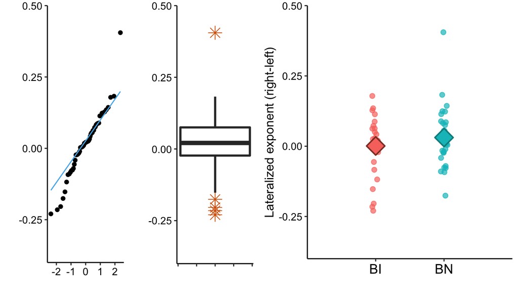

```r
exp1 <- ggplot(asm.wide, aes(sample= exp_lateralized)) +
         theme_classic() +
         geom_qq() + geom_qq_line(color= '#56B4E9') + labs(x= "") +
         scale_y_continuous(name= "", limits= c(-0.40,0.50), expand= c(0, 0)) +
         theme(axis.text= element_text(size= 10, color= "black"))
exp2 <- ggplot(asm.wide, aes(y= exp_lateralized)) +
         theme_classic() +
         geom_boxplot(size= 1, outlier.colour= "#D55E00", outlier.shape= 8, outlier.size= 4) + labs(x= "") +
         scale_y_continuous(name= "", limits= c(-0.40,0.50), expand= c(0, 0)) +
         theme(axis.text.y= element_text(size= 10, color= "black"), axis.text.x= element_text(color= "white"))
exp3 <- ggplot(asm.wide, aes(x= GRP, y= exp_lateralized, fill= GRP)) +
         geom_jitter(alpha= 0.7, width= 0.05, size= 2, aes(color= GRP)) +
         theme_classic() +
         stat_summary(fun.y= mean, shape= 23, size= 1.5, color= c("coral4","cyan4")) +
         scale_x_discrete(name= "", expand= c(1, 0)) +
         scale_y_continuous(name= "Lateralized exponent (right-left)", limits= c(-0.40,0.50), expand= c(0, 0)) +
         theme(axis.text.y= element_text(size= 10, color= "black"),
               axis.text.x= element_text(size= 13, color= "black"),
               axis.title= element_text(size= 12)) +
         theme(legend.position= "none")
layout2 <- rbind(c(1,2,3,3), c(1,2,3,3), c(1,2,3,3))
grid.arrange(arrangeGrob(exp1, exp2, exp3, layout_matrix= layout2))
```

```r
t.test(exp_lateralized~ GRP, data= asm.wide, var.equal= TRUE)
```

```
##
##  Two Sample t-test
##
## data:  exp_lateralized by GRP
## t = -1.056, df = 55, p-value = 0.2956
## alternative hypothesis: true difference in means is not equal to 0
## 95 percent confidence interval:
##  -0.08705142  0.02696895
## sample estimates:
## mean in group BI mean in group BN
##     0.0008642082     0.0309054410
```

```r
cor.test(asm.wide$exp_lateralized, asm.wide$ASM_trad, method= "pearson")
```

```
##
##  Pearson's product-moment correlation
##
## data:  asm.wide$exp_lateralized and asm.wide$ASM_trad
## t = 1.1176, df = 55, p-value = 0.2686
## alternative hypothesis: true correlation is not equal to 0
## 95 percent confidence interval:
##  -0.1160559  0.3942763
## sample estimates:
##       cor
## 0.1490181
```